# Exam_3

Carlos Nunez

11/29/2020

## Task 1

The main objective is to recreate figure 1 which is provided. First I began by loading the data, then viewed the data, cleaned the data, and finally visualized the data. In order to clean up the data first I rename the columns of interest, and then did pivot longer to organize data by transforming all of the professor’s ranks into a column called Rank, and their respective salaries into a column called Salary. And finally removed the Tier’s that weren’t of interest.

```r
#Load first dataset, call it data frame 1.
df1 <- read_csv("./FacultySalaries_1995.csv")
#view data
head(df1)

#Rename the columns of interest
df1 <- df1 %>% rename(Full = AvgFullProfSalary,
               Assoc = AvgAssocProfSalary,
               Assist = AvgAssistProfSalary)
#Clean up the data
Salary <-  pivot_longer(df1,-c(1:4,8:17),
                              names_to = "Rank",
                              values_to = "Salary", names_prefix = "Rank")

#Make a New table that excludes the Tier VIIB which is not of interest.
Salary1 <- filter(Salary, Tier == "I" | Tier == "IIA" | Tier == "IIB")
```

[output not shown]

This is the visualization of the cleaned data showing the influences that Rank and Tier have on Salary.

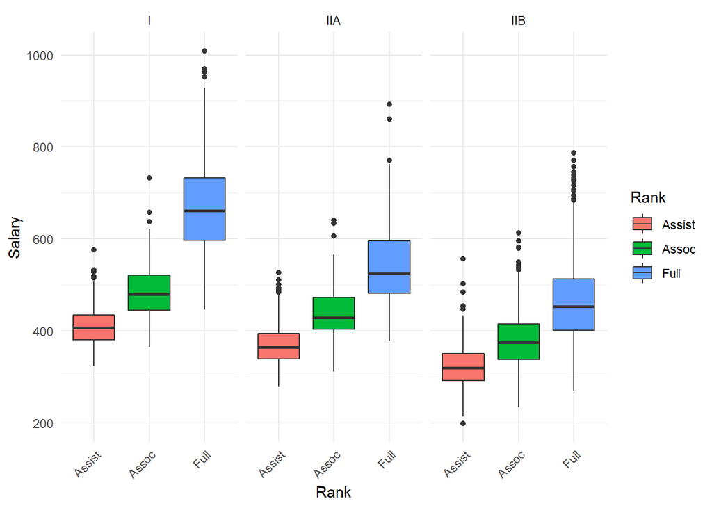

```r
q <- ggplot(Salary1, aes(x = Rank, y= Salary, fill = Rank))+
  geom_boxplot()+
  facet_wrap(~Tier)+
  labs(x="Rank")+
  theme_minimal()+
  theme(axis.text.x = element_text(angle = 45, hjust = 1))
q
```

```r
#Use ggsave to save the plot as jpg on the current working directory.
ggsave(filename = "NUNEZ_Fig_1.jpg",q)
```

## Task 2

Made an Anova table using the aov function, which is a more specific type of glm function.Afterwards I ran a summary function to help show how significant each independent variable is in its interactions with Salary.

```r
Anova_Table <- aov(data = Salary, formula =
                   Salary ~ State + Tier + Rank)
Anova_Table_Sum <- summary(Anova_Table)
Anova_Table_Sum
```

```
##               Df   Sum Sq Mean Sq F value Pr(>F)
## State         51  5682396  111420   30.66 <2e-16 ***
## Tier           2  7072361 3536180  972.96 <2e-16 ***
## Rank           2 16529771 8264885 2274.04 <2e-16 ***
## Residuals   3299 11990072    3634
## ---
## Signif. codes:  0 '***' 0.001 '**' 0.01 '*' 0.05 '.' 0.1 ' ' 1
## 128 observations deleted due to missingness
```

```r
# Export txt file into current working directory.
capture.output(Anova_Table_Sum, file = "./Salary_ANOVA_Summary.txt")
```

In Conclusion each of the independent variables is significant with respect to their interaction with Salary. Therefore the Professors Rank, Tier, and State they taught in all have significant impact on their Salaries.

## Task 3

Some of the main objective for this task are to load and clean up the data. Then to visualize the cleaned data and observe for the interactions of the variables of interest. To begin cleaning the data I used pivot longer. Selecting for all the Chemical columns of interest, and combining all the columns into one. And then assigned the values found within the original chemical columns which were the Mass-Spec Concentrations into a new column named Concentration.

```r
#First load the data set.
df2 <- read_csv("./Juniper_Oils.csv")
#clean up the data set.
df2_Chem <- pivot_longer(df2, cols = 11:33, names_to = "Chemical", values_to = "Concentration")
```

## Task 4

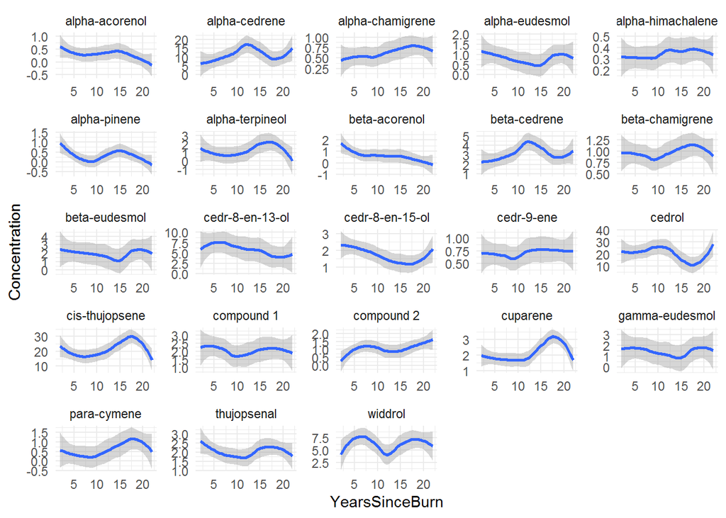

```r
#Visualize the cleaned up data.
p <- ggplot(df2_Chem, aes(x = YearsSinceBurn, y = Concentration))+
  geom_smooth()+
  facet_wrap(~Chemical, scales = "free")+
  theme_minimal()
p
```

```r
#Use ggsave to save the plot as jpg on the current working directory.
ggsave(filename = "NUNEZ_Fig_2.jpg",p)
```

## Task 5

For this task I made a generalized linear model, to help show which chemical concentrations were significantly affected by Years Since Burn. With a p-value < 0.05. Afterwards I used the tidy function to help make the data frame. Lastly the filter function was used to help select for the Chemical Concentrations with the most significant values in relation to Years Since Burn.

```r
mod1 <- glm(data = df2_Chem, formula = Concentration ~ YearsSinceBurn * Chemical)
Model1 <- tidy(mod1)
summary(mod1)
```

[output not shown]

```r
#Answer
SigChem <- filter(Model1, p.value < 0.05)
```